# Visión por computador. Práctica 1.

José Carlos Martínez Velázquez

15 de octubre de 2016

# A) Implementar una función de convolución my_imGaussConvol. debe ser capaz de calcular la convolución 2D de una imagen con una máscara. Ahora supondremos que la máscara es extraída del muestreo de una Gaussiana 2D simétrica. Para ello implementaremos las siguientes funciones auxiliares:

### 1).-Cálculo del vector máscara: Sea $f(x)=exp(-0.5 \frac{x^2}{\sigma^2})$ una función donde $\sigma$ representa un parámetro enunidades píxel. Implementar una función que, tomando $\sigma$ como parámetro de entrada devuelva una máscara de convolución representativa de dicha función. Justificar los pasos dados.

En primer lugar, debemos conocer la función que nos presentan. La función $f$ es una Gaussiana con media 0 y sigma variable (la damos nostros). Vamos a suponer un caso concreto, para entender bien cómo vamos a manipular la función en el caso general.

Supongamos $\sigma=2$, entonces nuestra función es la siguiente:

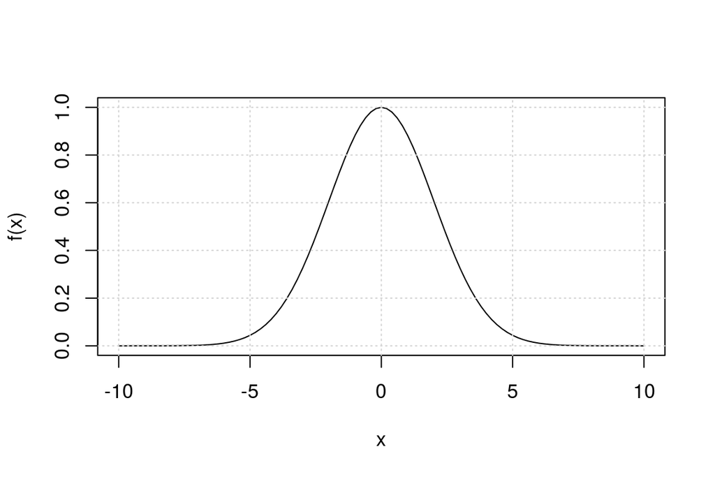

El siguiente paso es definir qué area es interesante para nosotros, es decir, a partir de qué valores de $x$, $f(x)$ es considerada nula (0). Para nosotros este valor es constante y será, para todos los casos $3\sigma$.

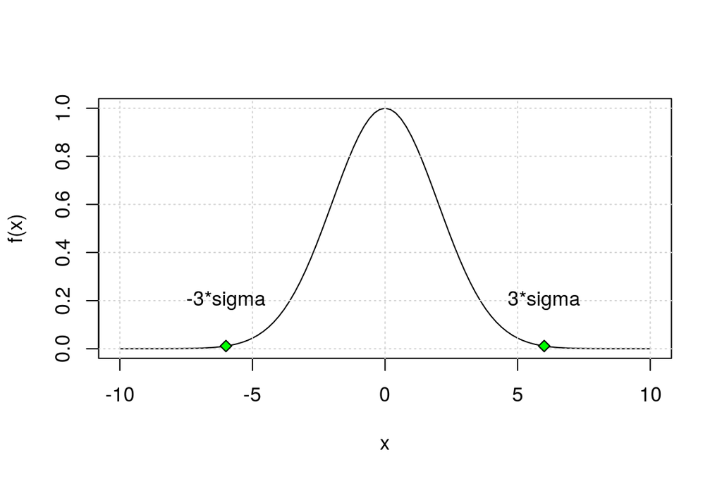

A partir de aquí, nuestro area de trabajo, es decir, lo que nos interesa de la función es el área sombreada. Podemos considerar que $\forall x < -3\sigma$, $f(x)=0$. Del mismo modo, $\forall x > 3\sigma$, $f(x)=0$.

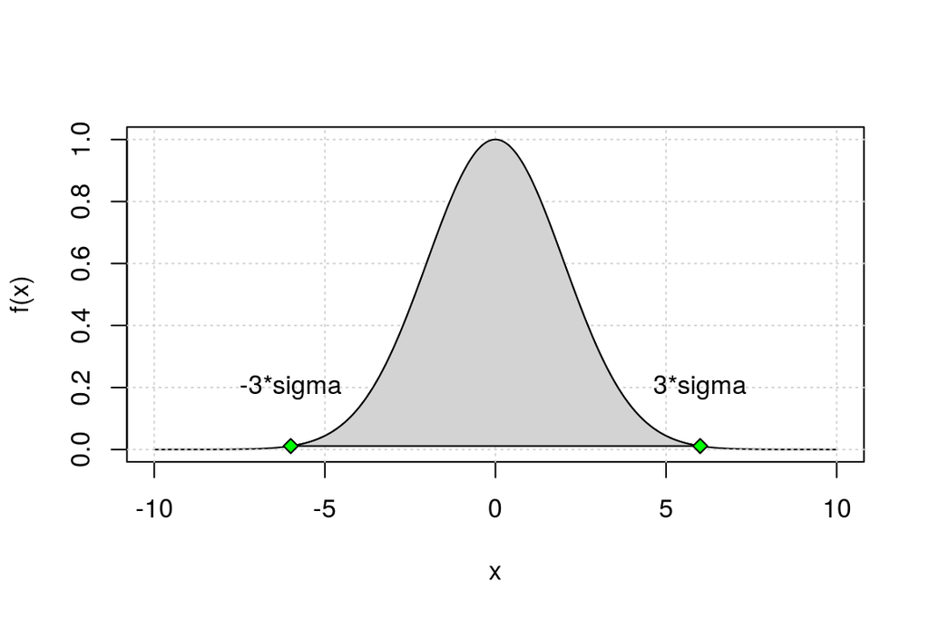

Llegados aquí, tenemos que discretizar la parte que nos interesa del area de seleccionada. Dado un valor de $\sigma$, nuestra máscara 1D contendrá $2(3*\sigma)+1$ valores, en nuestro caso de ejemplo, $2(3*2)+1=13$. Recordemos que la máscara debe siempre ser siempre impar. El proceso es muy simple. Necesitamos tomar $n=2(3*\sigma)+1$ muestras en un intervalo, pero ya conocemos una: $f(0)$, por lo que nos quedan que tomar $n-1=2(3*\sigma)$ muestras. La ventaja es que la función es simétrica, por lo que $f(a)=f(-a)$. Entonces, tenemos que tomar $\frac{n-1}{2}=\frac{2(3*\sigma)}{2}=(3*\sigma)$ muestras. Como tenemos que tomar $(3*\sigma)$ muestras en el intervalo $[0,3\sigma]$, la distancia entre cada valor muestreado en el eje x es de $\frac{3*\sigma}{3*\sigma}=1$

Todo esto justifica de forma analítica, que las muestras en el eje x deben tomarse de uno en uno, así, nuestra máscara estará formada por los siguientes valores:

$$f(-3\sigma),f(-3\sigma + 1),...,f(-1),f(0),f(1),...,f(3\sigma-1),f(3\sigma)$$

Dado que las funciones Gaussianas son simétricas, entonces, f(-a)=f(a). En lo que a cálculos se refiere, tenemos que hacer la mitad, luego sólo tenemos que calcular: $f(0),f(1),...,f(3\sigma-1),f(3\sigma)$, con lo que obtendríamos la función discretizada como sigue:

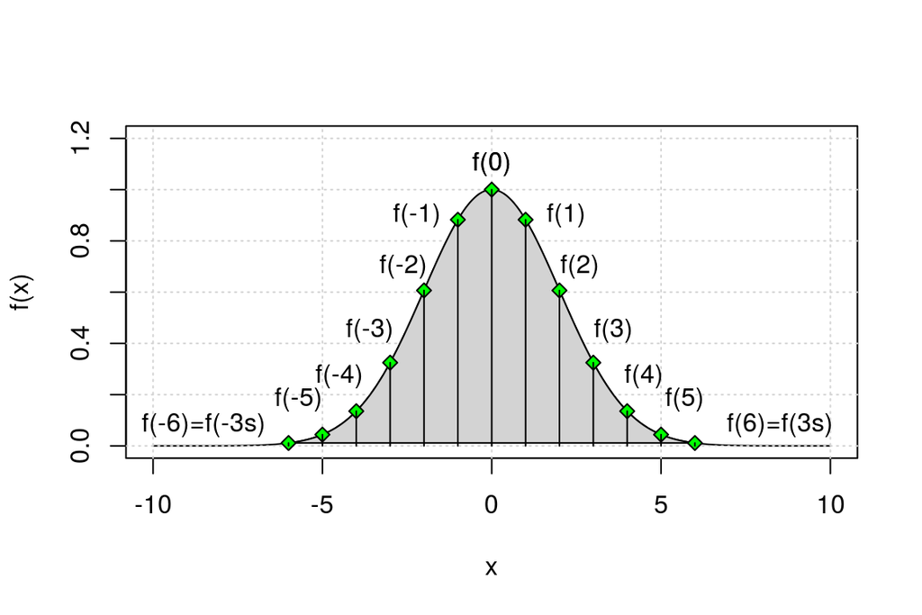

Una vez obtenidos todos los valores que formarán parte de la máscara, hay que multiplicarlos por un factor de normalización `normFactor`. Este paso se hace para que los valores de la máscara sumen 1. La razón de hacer esto es para evitar deformaciones en la imagen. En todos los casos, el factor de normalización es igual a la inversa de la suma de los valores de la máscara, es decir: $normFactor=\frac{1}{\sum_{i=1}^{k}mascara_i}$.

Teniendo claros estos pasos, la implementación de la obtención de la máscara es sencilla. Sólo tenemos que codificar la función $f$, calcular el tamaño de la máscara, que será un vector de $2(3*\sigma)+1$ posiciones. La posición 0 estará justo en el medio de dicho vector, por lo que la posición cero será la parte entera de $p0=\frac{2(3*\sigma)+1}{2}$. Entonces, `mascara1D[p0]=f(0,sigma)`. Ahora, hasta llegar a $3\sigma$, no tenemos mas que, en un bucle, rellenar los espacios que quedan: `mascara1D[p0+1]=mascara1D[p0-1]=f(1,sigma), ..., mascara1D[p0+3*sigma]=mascara1D[p0-3*sigma]=f(3*sigma,sigma)`. Por último nos quedaría devolver `mascara1D` multiplicada por el factor de normalización `normFactor`. Ni que decir tiene que, con esta implementación la máscara forzosamente queda simétrica, como debe ser. Esta función se llamará con la sentencia `getMask(sigma)` y su código, en Python sería implementado como sigue:

```python
"""
La funcion getMask recibe como parametro sigma, es decir el numero de
pixeles (numero de elementos) que tendra la mascara. Entenderemos como
relevantes aquellos valores que se encuentran como maximo a 3*sigma de
distancia de la media (0). GetMask devuelve un array con sigma elementos
donde cada elemento contiene el valor de f evaluado en la discretizacion
de la funcion.

Un ejemplo. Supongamos f con sigma=5. GetMask devolveria un vector de 5
elementos, que serian: |f(-15,5)|f(-7.5,5)|f(0,5)|f(15,5)|f(7.5,5)|.
Hay que multiplicar por un factor de normalizacion para que el valor de la
suma de todos los elementos de la mascara sumen 1.

"""
def getMask(sigma):
    sigma=abs(sigma)
    limit=3*sigma #DEFINIMOS EL LIMITE DE LA FUNCION F EN 3 SIGMAS
    #La longitud de la mascara va a ser 2*LIMITE+1, asi forzamos que sea impar
    mask1D=[0.0 for i in xrange((2*int(limit))+1)]
    lenMask=len(mask1D)
    positionzero=int(lenMask/2)
    mask1D[positionzero]=f(0,sigma)
    suma=mask1D[positionzero]
    for i in xrange(positionzero+1,lenMask):
        resultF=f(i-positionzero,sigma)
        mask1D[i]=resultF
        mask1D[(lenMask-1)-i]=resultF
        suma+=2*resultF
    normFactor=(1/suma)
    finalMask=[x * normFactor for x in mask1D]
    return finalMask
```

### 2).- Implementar una función que calcule la convolución de un vector señal 1D con un vector máscara 1D de longitud inferior al de la señal usando dos posibles tipos de condiciones de contorno (uniforme a ceros y reflejada). La salida será un vector de igual longitud que el vector señal de entrada.

##### 2.1) Paso 1: Implementar una función que calcule la convolución 1D entre dos vectores, dando de salida sólo los valores donde ha sido posible el cálculo.

Entendiendo el problema, la implementación consiste en calcular la primera posicion útil y la última: `startposition=parte\_entera(longitud(B)/2)` y `finishposition=(longitud(A)-1)-startposition`. A continuación colocamos el vector B con la posición central en `startposition` (basta con emparejar ambos vectores por el principio) y con un bucle la vamos moviendo de una en una posición hasta que la posición central de B esté emparejada con la última posición útil de A (que ambos vectores estén emparejados por el final), haciendo los cálculos pertinentes. Una vez el vector resultado ha sido calculado, basta con devolver lo que contiene el vector resultado desde la posición `startposition` hasta la posicion `finishposition` y habremos conseguido lo que buscábamos. Esta función se llamará mediante la sentencia `convolution2Vectors(mask,vect)` y se implementaría en Python como sigue:

```python
"""
La funcion convolution2Vectors
coge un vector y una mascara y calcula el filtrado del vector
con respecto de dicha mascara.

El tamaño de la mascara debe ser impar, pues el pixel central
es el que marca que pixel es para el que estamos calculando
los valores
"""
def convolution2Vectors(mask,vect):
    startPosition=len(mask)/2
    finishPosition=len(vect)-startPosition
    result=[
      sum([float(a*b) for a,b in zip(
                                      mask,
                                      vect[i-startPosition:i+startPosition+1]
                                    )
        ])for i in xrange(startPosition,finishPosition)]
    return result
```

##### 2.2) Definir un vector auxiliar de longitud mayor definida a partir de las dimensiones de los dos vectores de entrada. Por ejemplo, la señal tiene longitud N y el otro 2k+1, entonces el vector auxiliar será N+2k. Copiar en su centro el vector señal y rellenar los extremos usando el criterio de borde elegido.

Como hemos visto en el apartado 2.1, si queremos realizar el cálculo en toda la señal completa (vector A), no podíamos, pues había posiciones donde no se podía realizar el cálculo. Para solucionar esto, vamos a meter relleno por ambos lados del vector señal de forma que la posición central de la máscara (vector B) sea colocada en la posición 0 de la señal pudiendo así realizar los cálculos que faltaban.

Para introducir relleno, no nos hace falta mucho más de lo que tenemos. De hecho, calculando la variable `startposition` como en el apartado 2.1, sabemos cuántas posiciones de relleno hay que añadir por cada extremo del vector señal. Entonces, dado un vector señal y un vector máscara, calculamos un vector auxiliar de tantas posiciones como tenga el vector señal mas dos veces `startposition` (una vez al principio y otra al final). Es decir: `aux = [0.0] * (longitud(señal) + 2*startposition)`. (Este ejemplo inicializaría el vector auxiliar a 0). Ahora lo que queda es copiar el contenido del vector señal en las posiciones desde `startposition` hasta `finishposition` y devolver dicho vector auxiliar.

Una vez obtenido el vector auxiliar, las diferentes formas de rellenar los espacios introducidos son:

- Uniforme a ceros: No hay que hacer nada, simplemente si se ha inicializado el vector auxiliar a ceros, basta con devolverlo habiendo copiado la señal en su centro como acabamos de indicar.
- Reflejada: Consiste en extraer el vector de píxeles que va desde `startposition` hasta `2 * startposition`, darle la vuelta y colocarlo desde la posición 0 hasta `startposition-1`. Del mismo modo, por el final, se extrae el vector de píxeles que va desde `finishposition-startposition` hasta `finishposition`, darle la vuelta y colocarlo desde `finishposition+1` hasta `longitud(señal)-1`.
- Copia del primer y último pixel (no se pide): Consiste el coger el valor de la posición `startposition` y copiarlo desde la posición 0 hasta `startposition-1`. Del mismo modo, se coge el valor de la posición `finishposition` y copiarlo desde `finishposition+1` hasta la posición `longitud(señal)-1`.

Esta función se llamará mediante la sentencia `createAuxVector(mask,vect,borderType)` y su código en Python sería el siguiente:

```python
"""
La funcion createAuxVector corresponde al segundo paso del apartado 2).
De lo que se trata es de copiar los bordes ya sea constante a
cero o con reflejo o copia del ultimo pixel.
"""
def createAuxVector(mask,vect,borderType):
    result=np.array([0 for i in xrange(len(vect)+(len(mask)-1))])
    startPosition=len(mask)/2
    finishPosition=len(result)-startPosition
    result[startPosition:finishPosition]=vect

    #if(borderType==0): #Borde a ceros -> esta comentado porque no se haria nada

    if(borderType==1): #Borde reflejo
        result[0:startPosition]=result[2*startPosition:startPosition:-1]
        result[finishPosition:-1]=result[finishPosition-1:finishPosition-startPosition:-1]

    elif(borderType==2): #Borde copia
        result[0:startPosition]=result[startPosition]
        result[finishPosition:-1]=result[finishPosition-1]

    return result
```

### 3).- Implementar una función que tomando como entrada una imagen y el valor de sigma, calcule la convolución de dicha imagen con una máscara Gaussiana 2D. Usar las funciones implementadas en el punto anterior. Recordar que la Gaussiana es descomponible en convoluciones 1D por filas y columnas.

Esta función es un compendio de todo lo que hemos visto hasta ahora. En primer lugar, se obtiene la máscara con la llamada a la función `mask=getMask(sigma)`. Ahora separamos las capas con `r,g,b=cv2.split(imagen)`. Por cada capa R,G,B, debe seguirse el siguiente proceso: convertimos los valores de la capa al tipo `CV_32FC3`, es decir, flotantes de 32 bits, pues todos nuestros cálculos serán con números en coma flotante. A continuación, para cada fila (`vect`), obtendremos el vector auxiliar, con la llamada a la función `auxvec = createAuxVector(mask,vect,borderType)` al que se le aplicará la convolución 1D con la llamada a la función `convolution2Vectors(mask,auxvec)`. Una vez hecha la convolución 1D en horizontal, hay que hacerle la convolución 1D en vertical al resultado. Para ello basta con trasponer las capas (son matrices) y volver a aplicar el proceso de convolución 1D horizontal a cada una. Una vez terminado se vuelve a trasponer, para devolver cada capa a su estado original, se regresa al tipo `CV_8UC3` (valores enteros) para conventirla en una imagen que se pueda “pintar” y se reagrupa la imagen completa con `imagen=cv2.merge([r,g,b])`. Ahora la imagen puede ser mostrada.

El código en Python para hacer una convolución es el siguiente:

```python
"""
La funcion my_imGaussConvol realiza la convolucion de una imagen.
Los parametros que se usan son la imagen que se quiere convolucionar,
el sigma y el tipo de borde: 1 -> borde reflejo,
2-> borde copia, cualquier otro valor -> borde negro
"""
def my_imGaussConvol(image,sigma,bordertype):
    mask=getMask(sigma)
    r,g,b=cv2.split(image)

    #Trabajamos en modo CV_32FC3 (CALCULOS EN COMA FLOTANTE)
    r=np.float32(r)
    g=np.float32(g)
    b=np.float32(b)

    for i in xrange(len(r)):
        r[i]=convolution2Vectors(mask,createAuxVector(mask,r[i],bordertype))
        g[i]=convolution2Vectors(mask,createAuxVector(mask,g[i],bordertype))
        b[i]=convolution2Vectors(mask,createAuxVector(mask,b[i],bordertype))

        r=np.transpose(r)
        g=np.transpose(g)
        b=np.transpose(b)

        for i in xrange(len(r)):
            r[i]=convolution2Vectors(mask,createAuxVector(mask,r[i],bordertype))
            g[i]=convolution2Vectors(mask,createAuxVector(mask,g[i],bordertype))
            b[i]=convolution2Vectors(mask,createAuxVector(mask,b[i],bordertype))

        r=np.transpose(r)
        g=np.transpose(g)
        b=np.transpose(b)

    #Regresamos al modo CV_8UC3 (ENTERO)
    r=np.uint8(r)
    g=np.uint8(g)
    b=np.uint8(b)

    imgi=cv2.merge([r,g,b])
    return imgi
```

# B) Imágenes híbridas. Usar la función que hemos implementado en el apartado A para elegir los sigmas más adecuados para la selección de frecuencias en parejas de imágenes.

### 1) Implementar una función que genere las imágenes de baja y alta frecuencia.

El código en Python para conseguir este tipo de imágenes sería el siguiente:

```python
"""
La funcion getHighFrequences toma dos veces la misma imagen,
la original y la convolucionada. Resta la convolucionada a
la imagen original y obtenemos los detalles (altas frecuencias).
Se puede aplicar un filtro laplaciano, por lo que se pasa un coeficiente
laplaciano.
"""
def getHighFrequences(image,imageconv,hFfactor):
    r,g,b=cv2.split(image)

    #Trabajamos en modo CV_32FC3 (CALCULOS EN COMA FLOTANTE)
    r=np.float32(r)
    g=np.float32(g)
    b=np.float32(b)

    rc,gc,bc=cv2.split(imageconv)

    rc=np.float32(rc)
    gc=np.float32(gc)
    bc=np.float32(bc)

    r=hFfactor*r-rc
    g=hFfactor*g-gc
    b=hFfactor*b-bc

    r=normalize(r,0,255)
    g=normalize(g,0,255)
    b=normalize(b,0,255)

    #Regresamos al modo CV_8UC3 (ENTERO)
    r=np.uint8(r)
    g=np.uint8(g)
    b=np.uint8(b)

    finalimage=cv2.merge([r,g,b])

    return finalimage
```

La función de normalizado `normalize()` es el algoritmo de mapeo lineal y se hace por cada capa. Se obtendría el máximo y el mínimo de la capa (max y min actual) y, teniendo los nuevos máximo y mínimo al intervalo que queremos mapear, se aplica la siguiente expresión:

$$valor\_normalizado=\frac{(valor\_actual - min\_actual)(max\_nuevo-min\_nuevo)}{(max\_actual-min\_actual)} + min\_nuevo$$

El código en Python del normalizado es el siguiente:

```python
"""
La funcion normalize mapea un valor en un intervalo conocido al mismo valor
medido en un nuevo intervalo.
"""
def normalize(shape,min_v,max_v):
    if(min_v<max_v):
        maxvalue=256
        minvalue=0
        nshape=np.array([[0]*len(shape[0])]*len(shape))
        for i in xrange(len(shape)):
            for j in xrange(len(shape[0])):
                if(shape[i][j]>maxvalue):
                    maxvalue=shape[i][j]
                if(shape[i][j]<minvalue):
                    minvalue=shape[i][j]
        for i in xrange(len(shape)):
            for j in xrange(len(shape[0])):
                nshape[i][j]=((shape[i][j] - minvalue)*(max_v-min_v))
                            /(maxvalue-minvalue) + min_v
        return nshape
    else:
        raise ValueError, "min value in range must be smaller than max value in range."
```

A continuación, para obtener la imagen híbrida basta con sumar los pixeles de cada imagen y obtener la media. El código en Python sería el siguiente:

```python
"""
La funcion getHybridImage construye una imagen hibrida
a partir de dos imagenes. El primer parametro debe ser
una imagen correspondiente a las altas frecuencias
(extraidas previamente) y el segundo, una imagen alisada
convenientemente.
"""
def getHybridImage(imageHF,imageLF):
  #Trabajamos en coma flotante CV_32FC3
    imghf=np.float32(imageHF)
    imglf=np.float32(imageLF)
    hybridImage=(imghf+imglf)/2
    #Volvemos a entero CV_8UC3
    return np.uint8(hybridImage)
```

### 2) Escribir una función para mostrar las tres imágenes (alta, baja e híbrida) en una misma ventana.

El proceso es sencillo. Cargamos las dos imágenes que hacen falta en el color deseado. A continuación alisamos y obtenemos la imagen de alta frecuencia y la de baja. Hacemos la media de ambas imágenes y ya tendríamos el resultado deseado. El código es el siguiente.

```python
"""
Muestra solo la imagen de altas frecuencias, la de bajas frecuencias y la imagen hibrida.
"""
def showConstructionHybridImage(rutaAltas,colorAltas,sigmaAltas,
                                rutaBajas,colorBajas,sigmaBajas,
                                factorLaplaciano,border):

    imagenAltas=loadImage(rutaAltas,colorAltas)
    imagenBajas=loadImage(rutaBajas,colorBajas)

    imconv=my_imGaussConvol(imagenAltas,sigmaAltas,border)
    imAltas=getHighFrequences(imagenAltas,imconv,factorLaplaciano)

    imBajas=my_imGaussConvol(imagenBajas,sigmaBajas,border)

    hybridimage=getHybridImage(imAltas,imBajas)

    print("Esta viendo el proceso de construccion de la imagen hibrida,
    cierre la ventana para continuar.")

    paintMatrixImages(
        [[imAltas,imBajas,hybridimage]],
        [["Hi-FREQUENCES","Lo-FREQUENCES","HYBRID IMAGE"]],
        "Practica 1 - Vision por computador"
    )

    return hybridimage
```

# C) Construir una piramide Gaussiana de al menos 5 niveles con las imágenes híbridas calculadas en el apartado anterior. Mostrar los distintos niveles de la pirámide en un único canvas e interpretar el resultado.

En este apartado vamos a poner, para cada par de imágenes, el proceso de construcción de su imagen híbrida y su pirámide. Veremos procesos a escala de grises y a color para ver que la decisión tomada de triplicar las capas en el caso de escala de grises nos hace ganar en generalidad y que el mismo algoritmo funciona sea cual sea el tipo de color elegido.

\newpage

##### Einstein-Marilyn

Los parámetros utilizados son:

- $\sigma_{altas}:$ 1.8
- $\sigma_{bajas}:$ 6
- Factor laplaciano: 1 (sin cambios)
- Borde: 1 (reflejo)

\newpage

##### Avión-Ave

En esta segunda imagen a escala de gries nos enfrentamos a un cazabombardero superpuesto a un ave. Es dificil conseguir una imagen híbrida de calidad en este caso, pues los rasgos del ave sobre un fondo uniforme son difíciles de disolver.

Los parámetros utilizados son:

- $\sigma_{altas}:$ 1.7
- $\sigma_{bajas}:$ 8
- Factor laplaciano: 1 (sin cambios)
- Borde: 1 (reflejo)

\newpage

##### Bici-Moto

Para comprobar que los mismos algoritmos pueden ser empleados en imágenes a color que en imágenes en escala de grises, a partir de ahora, vamos a construir todas las imágenes híbridas con imágenes a color.

Los parámetros utilizados son:

- $\sigma_{altas}:$ 1.2
- $\sigma_{bajas}:$ 10
- Factor laplaciano: 1 (sin cambios)
- Borde: 1 (reflejo)

\newpage

##### Gato-Perro

Esta imagen es complicada de interpretar. La imagen en alta frecuencia del gato devuelve demasiados detalles en un espacio muy plano, por lo que fue necesario “exagerar” los cambios con un factor Laplaciano de 1.1 Esto permite restaltar los saltos un 10% más, lo cual parece suficiente. La imagen del perro tiene muchos detalles que se pueden intuir aún a muy baja frecuencia, ojos y nariz grandes, la silueta de la cabeza, etc. Lo cual necesita un $\sigma_{bajas}$ elevado para que no se perciban desde la cercanía.

Los parámetros utilizados son:

- $\sigma_{altas}:$ 2.5
- $\sigma_{bajas}:$ 10
- Factor laplaciano: 1.1 (Exagera los saltos en el gato un 10%)
- Borde: 1 (reflejo)

\newpage

##### Submarino-Pez

Los parámetros utilizados son:

- $\sigma_{altas}:$ 2
- $\sigma_{bajas}:$ 8
- Factor laplaciano: 1 (sin cambios)
- Borde: 1 (reflejo)

\newpage

El código para escalar hacia abajo (achicar) la imagen, alisa primero con un determinado $\sigma$ y posteriormente quita filas y columnas alternas para construir una imagen la mitad de grande que la anterior, manteniendo las proporciones. El código de esta función es el siguiente:

```python
"""
La funcion scaleDownImage se encarga de escalar a mas pequeña
una imagen, alisando la imagen y quitando filas y columnas
alternativamente
"""
def scaleDownImage(image,sigma,borderType):
    img=my_imGaussConvol(image,sigma,borderType)
    r,g,b=cv2.split(img)
    nrow=len(r)/2
    ncol=len(r[0])/2
    for i in xrange(0,nrow):
        r=np.delete(r,i,0) #Quitando arrays en el eje x (quitar filas)
        g=np.delete(g,i,0)
        b=np.delete(b,i,0)
    for i in xrange(0,ncol):
        r=np.delete(r,i,1) #Quitando arrays en el eje y (quitar columnas)
        g=np.delete(g,i,1)
        b=np.delete(b,i,1)
    return cv2.merge([r,g,b])
```

Por otro lado, la función que muestra la pirámide Gaussiana ha sido implementada a mano, esto es, sin utilizar funciones de OpenCV. La idea es crear una ventana, dividida en filas y columnas (las divisiones no son perceptibles). El numero de filas viene dado por el número de filas de la imagen original y el número de columnas por el número de columnas de la imagen original mas la mitad de estas, es decir, la anchura de la imagen original mas la anchura de la siguiente escala. Para dibujar, basta con indicar lo siguiente:

- La imagen original comienza en (0,0) y se extiende en su número de filas (`rowspan`) y su número de columnas (`colspan`) hacia abajo y a la derecha respectivamente.
- La segunda escala comienza en (0,colspan) y se extiende en rowspan/2 y colspan/2
- La tercera escala comienza en (rowspan/2) y se extiende en rowspan/4 y colspan/4

Así sucesivamente.

Lo primero es cerciorarse de que la imagen puede ser dividida tantas veces como indique la variable `level` para lo cual calculamos el logaritmo en base 2 del menor tamaño (numero de filas o de columnas). La imagen original ocupará todas las columnas de la parte izquierda (`ncol`) por lo que se inserará manualmente. La primera imagen de la escala será el principio de la recurrencia de la columna derecha, empezará en la posición (0,`ncol`) y es la excepción. A partir de aquí, habrá que ir calculando en qué fila empieza la siguiente imagen de forma recursiva. El código en Python que realiza esta acción es el siguiente:

```python
"""
Calcula y pinta la piramide gaussiana de una imagen a level niveles
"""
def showPyramid(imagen,windowtitle,sigma,border,level):
    nrow=len(imagen)
    ncol=len(imagen[0])

    min_size=min(nrow,ncol)

    if(level<math.log(min_size,2)):
        fig = plt.figure()
        fig.canvas.set_window_title(windowtitle)

        ax1=plt.subplot2grid((nrow,ncol+ncol/2),
              (0,0), rowspan=nrow,colspan=ncol)
        plt.xticks([]),plt.yticks([])
        plt.imshow(imagen)

        i=0
        rowini=i
        row_span=nrow/2**(i+1)
        col_span=ncol/2**(i+1)

        img1=scaleDownImage(imagen,sigma,border)
        ax2 = plt.subplot2grid((nrow,ncol+ncol/2),
              (rowini,ncol), rowspan=row_span,colspan=col_span)
        plt.xticks([]),plt.yticks([])
        plt.imshow(img1)

        for i in xrange(1,level-1):
            rowini+=row_span
            row_span=nrow/2**(i+1)
            col_span=ncol/2**(i+1)

            imgbucle=scaleDownImage(img1,sigma,border)
            plt.subplot2grid((nrow,ncol+ncol/2),
                  (rowini, ncol), rowspan=row_span, colspan=col_span)
            plt.xticks([]),plt.yticks([])
            plt.imshow(imgbucle)

            img1=imgbucle
        print("Esta viendo la piramide gaussiana, cierre la ventana para continuar.")
        plt.show()
    else:
        raise ValueError,
          "Image cannot be scaled down more than "+math.log(min_size,2)+" times."
```

# Cuestiones técnicas

- bicycle.bmp
- bird.bmp
- cat.bmp
- dog.bmp
- einstein.bmp
- fish.bmp
- marilyn.bmp
- motorcycle.bmp
- plane.bmp
- submarine.bmp